# SVM-final1

```python
import pandas as pd
import numpy as np
import matplotlib.pyplot as plt
import seaborn as sns

from sklearn.model_selection import train_test_split, GridSearchCV
from sklearn.preprocessing import StandardScaler
from sklearn.metrics import classification_report, confusion_matrix, ConfusionMatrixDisplay, accuracy_score,precision_score,recall_score

from xgboost import XGBClassifier, plot_importance
from sklearn.ensemble import RandomForestClassifier
from sklearn.svm import SVC
```

```python
import pandas as pd
import os

data_dir = "/Users/wangqiyang/Desktop/542final"


print(os.listdir(data_dir))


df = pd.read_csv(os.path.join(data_dir, "covtype.csv"))

df.head()
```

```
['Illinois_stat542_final.pptx', '.DS_Store', 'Untitled-1.ipynb', 'covtype.csv', 'Untitled-1.html', '~$Illinois_stat542_final.pptx']
```

|  | Elevation | Aspect | Slope | Horizontal_Distance_To_Hydrology | Vertical_Distance_To_Hydrology | Horizontal_Distance_To_Roadways | Hillshade_9am | Hillshade_Noon | Hillshade_3pm | Horizontal_Distance_To_Fire_Points | ... | Soil_Type32 | Soil_Type33 | Soil_Type34 | Soil_Type35 | Soil_Type36 | Soil_Type37 | Soil_Type38 | Soil_Type39 | Soil_Type40 | Cover_Type |
| --- | --- | --- | --- | --- | --- | --- | --- | --- | --- | --- | --- | --- | --- | --- | --- | --- | --- | --- | --- | --- | --- |
| 0 | 2596 | 51 | 3 | 258 | 0 | 510 | 221 | 232 | 148 | 6279 | ... | 0 | 0 | 0 | 0 | 0 | 0 | 0 | 0 | 0 | 5 |
| 1 | 2590 | 56 | 2 | 212 | -6 | 390 | 220 | 235 | 151 | 6225 | ... | 0 | 0 | 0 | 0 | 0 | 0 | 0 | 0 | 0 | 5 |
| 2 | 2804 | 139 | 9 | 268 | 65 | 3180 | 234 | 238 | 135 | 6121 | ... | 0 | 0 | 0 | 0 | 0 | 0 | 0 | 0 | 0 | 2 |
| 3 | 2785 | 155 | 18 | 242 | 118 | 3090 | 238 | 238 | 122 | 6211 | ... | 0 | 0 | 0 | 0 | 0 | 0 | 0 | 0 | 0 | 2 |
| 4 | 2595 | 45 | 2 | 153 | -1 | 391 | 220 | 234 | 150 | 6172 | ... | 0 | 0 | 0 | 0 | 0 | 0 | 0 | 0 | 0 | 5 |

5 rows × 55 columns

```python
from sklearn.model_selection import train_test_split

# Feature/label split + stratified sampling + train/test split

# Split features and target
X = df.drop(columns=["Cover_Type"])
# shift labels from 1–7 to 0–6
y = df["Cover_Type"] - 1

# Stratified random sampling: keep 100,000 rows, preserve class proportions
X_sample, _, y_sample, _ = train_test_split(
    X, y,
    train_size=100000,
    stratify=y,
    random_state=42
)

print("Sampled class distribution:")
print(y_sample.value_counts())

# Train/Test split on the sampled data
X_train, X_test, y_train, y_test = train_test_split(
    X_sample, y_sample,
    test_size=0.2,
    random_state=42,
    stratify=y_sample
)

print("Train shape:", X_train.shape)
print("Test shape:", X_test.shape)
```

```
Sampled class distribution:
Cover_Type
1    48760
0    36460
2     6154
6     3530
5     2989
4     1634
3      473
Name: count, dtype: int64
Train shape: (80000, 54)
Test shape: (20000, 54)
```

```python
df.head(10)
X_train.head(10)
```

|  | Elevation | Aspect | Slope | Horizontal_Distance_To_Hydrology | Vertical_Distance_To_Hydrology | Horizontal_Distance_To_Roadways | Hillshade_9am | Hillshade_Noon | Hillshade_3pm | Horizontal_Distance_To_Fire_Points | ... | Soil_Type31 | Soil_Type32 | Soil_Type33 | Soil_Type34 | Soil_Type35 | Soil_Type36 | Soil_Type37 | Soil_Type38 | Soil_Type39 | Soil_Type40 |
| --- | --- | --- | --- | --- | --- | --- | --- | --- | --- | --- | --- | --- | --- | --- | --- | --- | --- | --- | --- | --- | --- |
| 480783 | 3133 | 333 | 10 | 408 | -52 | 1237 | 197 | 228 | 169 | 1027 | ... | 0 | 0 | 0 | 0 | 0 | 0 | 0 | 0 | 0 | 0 |
| 384722 | 3250 | 173 | 18 | 30 | -3 | 2206 | 228 | 246 | 142 | 738 | ... | 0 | 0 | 0 | 0 | 0 | 0 | 0 | 0 | 0 | 0 |
| 282532 | 2227 | 90 | 28 | 42 | 11 | 1600 | 249 | 185 | 46 | 247 | ... | 0 | 0 | 0 | 0 | 0 | 0 | 0 | 0 | 0 | 0 |
| 281819 | 2269 | 284 | 10 | 108 | 25 | 1699 | 191 | 240 | 189 | 902 | ... | 0 | 0 | 0 | 0 | 0 | 0 | 0 | 0 | 0 | 0 |
| 237595 | 2960 | 198 | 9 | 234 | 14 | 1832 | 217 | 248 | 165 | 2106 | ... | 0 | 1 | 0 | 0 | 0 | 0 | 0 | 0 | 0 | 0 |
| 219320 | 3175 | 15 | 7 | 85 | 7 | 2506 | 214 | 225 | 148 | 2671 | ... | 0 | 0 | 0 | 0 | 0 | 0 | 0 | 0 | 0 | 0 |
| 158686 | 3070 | 126 | 16 | 124 | 43 | 4806 | 245 | 227 | 105 | 2965 | ... | 0 | 0 | 0 | 0 | 0 | 0 | 0 | 0 | 0 | 0 |
| 154090 | 2950 | 79 | 11 | 234 | 54 | 3610 | 235 | 220 | 115 | 2852 | ... | 0 | 0 | 0 | 0 | 0 | 0 | 0 | 0 | 0 | 0 |
| 182995 | 3033 | 329 | 11 | 277 | 77 | 2167 | 193 | 227 | 173 | 1167 | ... | 0 | 0 | 0 | 0 | 0 | 0 | 0 | 0 | 0 | 0 |
| 334659 | 2546 | 335 | 13 | 400 | 77 | 124 | 191 | 223 | 171 | 713 | ... | 0 | 0 | 0 | 0 | 0 | 0 | 0 | 0 | 0 | 0 |

10 rows × 54 columns

# Data analysis and visualization

```python
continuous_cols = [
    col for col in X.columns
    if not col.startswith("Wilderness") and not col.startswith("Soil")
]

df[continuous_cols].describe().T[['min', 'max']]
```

|  | min | max |
| --- | --- | --- |
| Elevation | 1859.0 | 3858.0 |
| Aspect | 0.0 | 360.0 |
| Slope | 0.0 | 66.0 |
| Horizontal_Distance_To_Hydrology | 0.0 | 1397.0 |
| Vertical_Distance_To_Hydrology | -173.0 | 601.0 |
| Horizontal_Distance_To_Roadways | 0.0 | 7117.0 |
| Hillshade_9am | 0.0 | 254.0 |
| Hillshade_Noon | 0.0 | 254.0 |
| Hillshade_3pm | 0.0 | 254.0 |
| Horizontal_Distance_To_Fire_Points | 0.0 | 7173.0 |

```python
print("Elevation range:", df['Elevation'].min(), "-", df['Elevation'].max())
print("Slope range:", df['Slope'].min(), "-", df['Slope'].max())

distance_cols = [c for c in continuous_cols if "Distance" in c]
print("Distance min/max:", df[distance_cols].min().min(), "-", df[distance_cols].max().max())

hillshade_cols = [c for c in continuous_cols if "Hillshade" in c]
print("Hillshade min/max:", df[hillshade_cols].min().min(), "-", df[hillshade_cols].max().max())

wilderness_cols = [c for c in df.columns if c.startswith("Wilderness")]
soil_cols = [c for c in df.columns if c.startswith("Soil")]
print("Wilderness unique:", sorted(df[wilderness_cols].stack().unique()))
print("Soil unique:", sorted(df[soil_cols].stack().unique()))
```

```
Elevation range: 1859 - 3858
Slope range: 0 - 66
Distance min/max: -173 - 7173
Hillshade min/max: 0 - 254
Wilderness unique: [0, 1]
Soil unique: [0, 1]
```

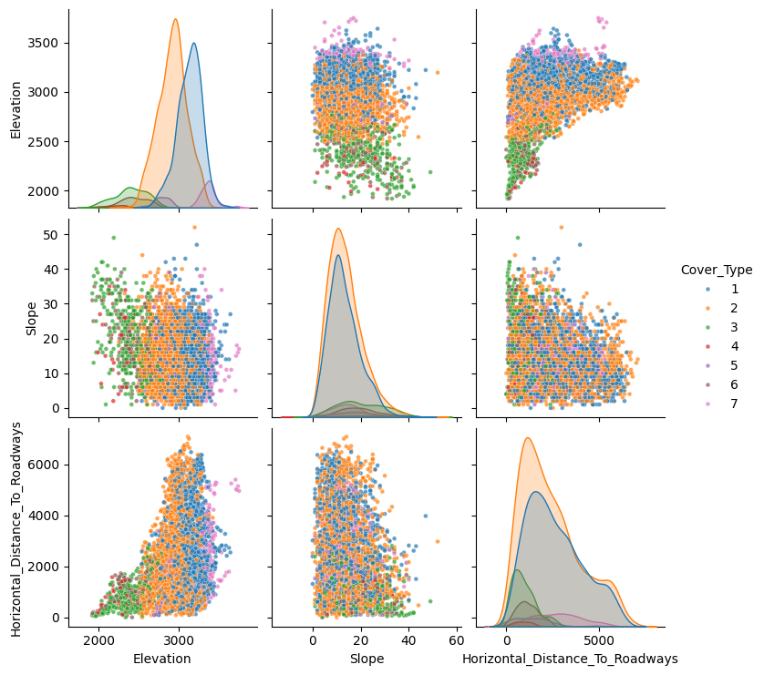

```python
import seaborn as sns
import matplotlib.pyplot as plt

sample = df.sample(5000, random_state=42)

sns.pairplot(
    sample,
    vars=["Elevation", "Slope", "Horizontal_Distance_To_Roadways"],
    hue="Cover_Type",
    palette="tab10",
    plot_kws={"alpha": 0.7, "s": 12}
    # corner=True,
)

plt.show()
```

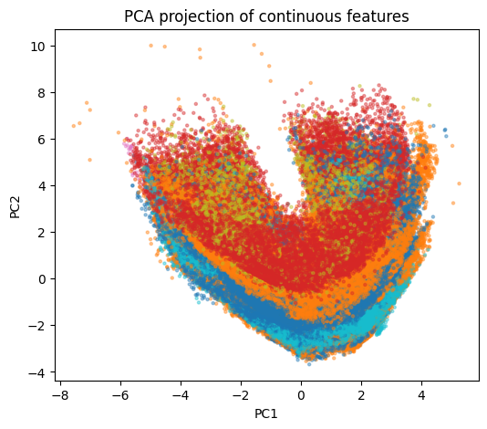

```python
from sklearn.decomposition import PCA
from sklearn.preprocessing import StandardScaler
import matplotlib.pyplot as plt
scaler = StandardScaler()
X_scaled = scaler.fit_transform(X[continuous_cols])

pca = PCA(n_components=2)
X_pca = pca.fit_transform(X_scaled)

plt.figure(figsize=(6, 5))
plt.scatter(X_pca[:, 0], X_pca[:, 1], c=y, s=5, alpha=0.4, cmap="tab10")
plt.xlabel("PC1")
plt.ylabel("PC2")
plt.title("PCA projection of continuous features")
plt.show()
```

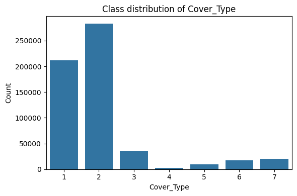

```
Class proportions:
Cover_Type
1    0.364605
2    0.487599
3    0.061537
4    0.004728
5    0.016339
6    0.029891
7    0.035300
Name: proportion, dtype: float64
```

```python
import matplotlib.pyplot as plt
import seaborn as sns
cover_counts = df["Cover_Type"].value_counts().sort_index()
cover_props  = df["Cover_Type"].value_counts(normalize=True).sort_index()
plt.figure(figsize=(6,4))
sns.barplot(x=cover_counts.index, y=cover_counts.values)
plt.xlabel("Cover_Type")
plt.ylabel("Count")
plt.title("Class distribution of Cover_Type")
plt.tight_layout()
plt.show()

print("Class proportions:")
print(cover_props)
```

### Exploratory Data Analysis

We first explored the structure of the Forest Cover Type dataset before fitting any models.

**Feature groups.**  
The predictors naturally fall into three groups:

- **Continuous topographic and distance variables (10):**  
  `Elevation`, `Aspect`, `Slope`, `Horizontal_Distance_To_Hydrology`,  
  `Vertical_Distance_To_Hydrology`, `Horizontal_Distance_To_Roadways`,  
  `Horizontal_Distance_To_Fire_Points`, `Hillshade_9am`, `Hillshade_Noon`, `Hillshade_3pm`.
- **Wilderness indicators (4 binary):** `Wilderness_Area1`–`Wilderness_Area4`.
- **Soil type indicators (40 binary):** `Soil_Type1`–`Soil_Type40`.

The response variable **`Cover_Type`** is a 7-class label indicating the dominant forest cover type (tree species) on each 30m × 30m plot.

#### Basic summaries

Using `describe()` on the continuous variables, we observe very different numeric scales:

- **Elevation:** about 1850–3850 meters.
- **Slope:** 0–66 degrees.
- **Distance variables:** roughly 0–7000+ meters.
- **Hillshade:** bounded between 0 and 254.

In contrast, all `Wilderness_Area*` and `Soil_Type*` variables are 0/1 indicators.  
This motivates our preprocessing choice: we apply **z-score standardization only to the continuous features** and keep the binary indicators on their original 0/1 scale.

#### Class distribution of `Cover_Type`

The bar chart of `Cover_Type` shows a **clearly imbalanced** class distribution:

- Classes **1** and **2** are dominant.
- Class **3** is much less frequent.
- Classes **4–7** are rare.

Therefore, overall accuracy can be misleading; in later experiments we will also report **per-class metrics and macro-averaged scores** to properly assess performance on minority classes.

#### Pairwise relationships

A Seaborn pairplot of three representative continuous features  
(`Elevation`, `Slope`, `Horizontal_Distance_To_Roadways`) colored by `Cover_Type` shows that:

- Different cover types prefer different ranges of elevation and distance to roadways,  
  but their one-dimensional distributions overlap substantially.
- In the 2D scatter plots, the classes form **structured but heavily overlapping clouds**, and the apparent class boundaries are **curved rather than linear**.

This indicates that no single feature can separate the seven classes and that simple linear decision boundaries are unlikely to perform well.

#### PCA projection

After standardizing the 10 continuous features, we apply PCA and project them onto the first two principal components:

- In the PC1–PC2 plane, the data lie on a **curved, U-shaped manifold**, reflecting strong correlations among the continuous variables.
- The seven cover types occupy different regions along this manifold, but still **overlap considerably**, and there is no obvious linear separator.

This global view further confirms that the underlying decision boundaries are **highly non-linear**.

#### Takeaways for modeling

From the EDA we conclude that:

1. The task is a **7-class classification problem** with purely numeric predictors.
2. Continuous features have very different scales, while wilderness and soil variables are binary; we therefore **standardize only the continuous covariates**.
3. Pairplots and PCA reveal **overlapping but structured clusters** and **non-linear class boundaries**, which motivates using a **flexible non-linear classifier**, such as an SVM with an RBF kernel (and tree-based methods) as our main models.
4. Because of **class imbalance**, model evaluation should not rely on accuracy alone; we will also inspect confusion matrices and macro-averaged metrics to understand performance on minority classes.

### Why SVM?

We choose Support Vector Machines (SVM) because they are margin-based classifiers that work well on medium-sized, high-dimensional tabular data such as the Forest Cover Type dataset. Instead of only minimizing the training error, SVM explicitly maximizes the margin between classes, which tends to improve generalization, especially when some classes are rare. SVMs are also fairly robust to noisy features and can handle multi-class classification via one-vs-rest or one-vs-one schemes, which we use for the 7 cover types.

### Why do we scale the features?

Feature scaling is crucial for SVM because the algorithm depends on inner products and distances between observations. In the linear case, the decision function is built from dot products (x_i^\top x_j); with the RBF kernel it explicitly uses the squared Euclidean distance (|x_i - x_j|^2). If the original variables are on very different scales (e.g., elevation in thousands vs. slope in tens), large-scale features would dominate these distances and the SVM would effectively ignore smaller-scale variables. By standardizing all continuous features to have mean 0 and variance 1, we put them on a comparable scale, make the optimization more stable, and ensure that the hyperparameters (C) and (\gamma) have a meaningful and consistent effect on the model.

### Why use kernels (especially the RBF kernel)?

The EDA and PCA projection suggest that the relationship between the environmental features and the cover types is highly non-linear; the different classes are heavily intertwined in the original feature space. A purely linear SVM would therefore be too rigid and underfit the data. Kernel SVMs address this by implicitly mapping the inputs into a higher-dimensional feature space, where the classes are more likely to be (almost) linearly separable.

In particular, the RBF (Gaussian) kernel [ K(x, x') = \exp(-\gamma |x - x'|^2) ] can model complex, localized decision boundaries and does not require us to manually construct polynomial or interaction features. It is a good default choice for non-linear structure in tabular data.

### Interpretation of (C) and (\gamma) in this task

- **(C) (regularization parameter in SVM)**  
  (C) controls the trade-off between maximizing the margin and penalizing misclassified training points (the slack variables).
  - **Large (C)**: the model puts more weight on classifying the training data correctly, allowing a smaller margin and fitting more complex boundaries → lower bias but higher risk of overfitting.
  - **Small (C)**: the model allows more training errors in exchange for a wider margin and smoother boundary → higher bias but better regularization and robustness.
- **(\gamma) (RBF kernel width)**  
  (\gamma) controls how fast the kernel similarity decays with distance.
  - **Large (\gamma)**: each point only influences a small neighborhood, leading to very wiggly, highly local decision boundaries → can fit fine details but easily overfits noise.
  - **Small (\gamma)**: similarity decays slowly, so each point influences a broad region → smoother, more global decision boundary that may underfit complex patterns.

In our cover-type classification problem, tuning (C) and (\gamma) allows us to balance underfitting vs. overfitting and to adapt the complexity of the decision surface to the non-linear structure we observed in the EDA.

```python
from sklearn.pipeline import Pipeline
from sklearn.preprocessing import StandardScaler
from sklearn.svm import SVC
from sklearn.model_selection import GridSearchCV
from sklearn.metrics import accuracy_score, classification_report, confusion_matrix

# Pipeline: scaling on X_train only, then SVM
svm_pipe = Pipeline([
    ("scaler", StandardScaler()),
    ("svm", SVC(kernel="rbf", decision_function_shape="ovr"))
])

# Hyperparameter grid for C and gamma
param_grid = {
    "svm__C": [1, 10, 100],
    "svm__gamma": [0.01, 0.1, 1.0]
}

# Grid search ONLY on the training set
grid = GridSearchCV(
    estimator=svm_pipe,
    param_grid=param_grid,
    cv=3,
    scoring="accuracy",
    n_jobs=-1,
    verbose=1
)


grid.fit(X_train, y_train)

print("Best parameters:", grid.best_params_)
print("Best CV accuracy on training set:", grid.best_score_)


best_model = grid.best_estimator_
y_pred = best_model.predict(X_test)

print("\nTest accuracy:", accuracy_score(y_test, y_pred))
print("\nClassification report on test set:")
print(classification_report(y_test, y_pred))

print("\nConfusion matrix (rows: true, cols: predicted):")
print(confusion_matrix(y_test, y_pred))
```

```
Fitting 3 folds for each of 9 candidates, totalling 27 fits
Best parameters: {'svm__C': 10, 'svm__gamma': 1.0}
Best CV accuracy on training set: 0.8701999996469331

Test accuracy: 0.89335

Classification report on test set:
              precision    recall  f1-score   support

           0       0.90      0.89      0.90      7292
           1       0.90      0.92      0.91      9752
           2       0.87      0.85      0.86      1231
           3       0.82      0.71      0.76        94
           4       0.79      0.68      0.73       327
           5       0.78      0.69      0.73       598
           6       0.92      0.87      0.89       706

    accuracy                           0.89     20000
   macro avg       0.85      0.80      0.83     20000
weighted avg       0.89      0.89      0.89     20000


Confusion matrix (rows: true, cols: predicted):
[[6518  715    1    0    6    2   50]
 [ 643 8989   39    0   46   30    5]
 [   1   88 1046    9    5   82    0]
 [   0    9   15   67    0    3    0]
 [  12   89    2    0  221    3    0]
 [   8   70   99    6    0  415    0]
 [  65   30    0    0    0    0  611]]
```

### SVM model: results summary

We trained a multi-class SVM with an RBF kernel on the sampled Cover_Type data  
(80,000 training samples, 20,000 test samples, stratified by class).

**Conclusion.**  
The tuned RBF-SVM achieves strong overall performance (≈89% test accuracy) and models the majority classes very well, but performance on minority classes is lower due to label imbalance and their more complex decision boundaries. Future work could explore class-weighted SVMs or resampling strategies to further improve recall for the rare cover types.

```python
from sklearn.model_selection import train_test_split
from sklearn.pipeline import Pipeline
from sklearn.preprocessing import StandardScaler
from sklearn.svm import SVC
from sklearn.metrics import accuracy_score, classification_report, confusion_matrix


X_train_bal, _, y_train_bal, _ = train_test_split(
    X_train, y_train,
    train_size=30000,
    stratify=y_train,
    random_state=42
)

svm_balanced = Pipeline([
    ("scaler", StandardScaler()),
    ("svm", SVC(
        kernel="rbf",
        C=10,
        gamma=1.0,
        class_weight="balanced"
    ))
])

svm_balanced.fit(X_train_bal, y_train_bal)
y_pred_bal = svm_balanced.predict(X_test)

print("Balanced SVM (subset train) – Test accuracy:",
      accuracy_score(y_test, y_pred_bal))
print("\nBalanced SVM – classification report:")
print(classification_report(y_test, y_pred_bal))
print("\nBalanced SVM – confusion matrix:")
print(confusion_matrix(y_test, y_pred_bal))


svm_unbalanced = Pipeline([
    ("scaler", StandardScaler()),
    ("svm", SVC(
        kernel="rbf",
        C=10,
        gamma=1.0,

    ))
])

svm_unbalanced.fit(X_train_bal, y_train_bal)
y_pred_unbal = svm_unbalanced.predict(X_test)

print("\n" + "="*60)
print("Unbalanced SVM (subset train) – Test accuracy:",
      accuracy_score(y_test, y_pred_unbal))
print("\nUnbalanced SVM – classification report:")
print(classification_report(y_test, y_pred_unbal))
print("\nUnbalanced SVM – confusion matrix:")
print(confusion_matrix(y_test, y_pred_unbal))
```

```
Balanced SVM (subset train) – Test accuracy: 0.83815

Balanced SVM – classification report:
              precision    recall  f1-score   support

           0       0.85      0.85      0.85      7292
           1       0.85      0.88      0.86      9752
           2       0.82      0.75      0.79      1231
           3       0.77      0.43      0.55        94
           4       0.68      0.54      0.60       327
           5       0.67      0.57      0.62       598
           6       0.86      0.75      0.80       706

    accuracy                           0.84     20000
   macro avg       0.78      0.68      0.72     20000
weighted avg       0.84      0.84      0.84     20000


Balanced SVM – confusion matrix:
[[6176 1021    1    0   13    4   77]
 [ 998 8573   57    0   65   49   10]
 [   0  181  926    7    5  112    0]
 [   0   27   23   40    0    4    0]
 [  11  130    6    0  177    3    0]
 [   8  131  111    5    1  342    0]
 [  96   81    0    0    0    0  529]]

============================================================
Unbalanced SVM (subset train) – Test accuracy: 0.8382

Unbalanced SVM – classification report:
              precision    recall  f1-score   support

           0       0.85      0.84      0.84      7292
           1       0.84      0.89      0.86      9752
           2       0.83      0.75      0.79      1231
           3       0.77      0.43      0.55        94
           4       0.71      0.51      0.60       327
           5       0.68      0.55      0.61       598
           6       0.88      0.74      0.80       706

    accuracy                           0.84     20000
   macro avg       0.79      0.67      0.72     20000
weighted avg       0.84      0.84      0.84     20000


Unbalanced SVM – confusion matrix:
[[6114 1101    1    0    9    3   64]
 [ 935 8668   47    0   56   39    7]
 [   1  185  929    7    4  105    0]
 [   0   27   24   40    0    3    0]
 [  15  134    7    0  168    3    0]
 [  14  137  116    5    0  326    0]
 [ 106   81    0    0    0    0  519]]
```

### Balanced vs. Unbalanced SVM on a 30k Training Subset

To study the effect of class weighting, I trained two RBF–kernel SVMs on the **same 30,000-sample stratified subset** of the training data.  
Both models use the hyper-parameters found by the previous grid search (`C = 10`, `gamma = 1.0`); the only difference is whether we use class weights.

- **Balanced SVM**: `class_weight="balanced"`
- **Unbalanced SVM**: default `class_weight=None`

Both models are evaluated on the full 20,000-sample test set.

**Global performance**

| Model | Test accuracy | Macro precision | Macro recall | Macro F1 |
| --- | --- | --- | --- | --- |
| Balanced SVM (`class_weight="balanced"`) | 0.838 | 0.78 | 0.68 | 0.72 |
| Unbalanced SVM (`class_weight=None`) | 0.838 | 0.79 | 0.67 | 0.72 |

The overall test accuracy is essentially the same for both models.  
However, the balanced SVM has slightly **higher macro recall**, meaning it recovers minority classes a bit better, while the unbalanced SVM has slightly **higher macro precision**.

SVM+PCA

```python
import pandas as pd
import numpy as np
import matplotlib.pyplot as plt
import seaborn as sns
from sklearn.model_selection import train_test_split
from sklearn.preprocessing import StandardScaler
from sklearn.decomposition import PCA
from sklearn.svm import SVC
from sklearn.metrics import (
    accuracy_score,
    precision_score,
    recall_score,
    classification_report,
    confusion_matrix
)
```

```
Sampled class distribution (normalized):
Cover_Type
1    0.488
0    0.365
2    0.062
6    0.035
5    0.030
4    0.016
3    0.005
Name: proportion, dtype: float64

Train set shape: (80000, 54), Test set shape: (20000, 54)
Processed train set shape: (80000, 54)
```

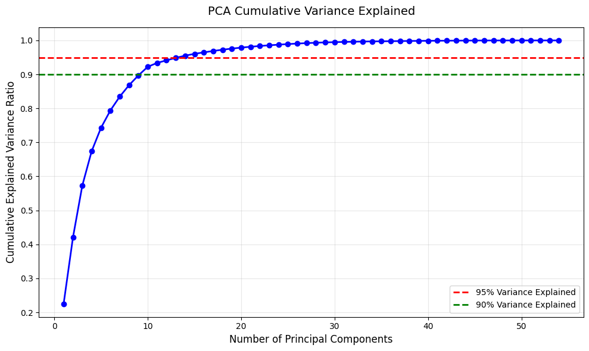

[output not shown]

[output cut: 56 more lines]

```

Classification Report:
              precision    recall  f1-score   support

     Class 1       0.83      0.79      0.81      7292
     Class 2       0.82      0.88      0.85      9752
     Class 3       0.75      0.85      0.80      1231
     Class 4       0.81      0.59      0.68        94
     Class 5       0.92      0.26      0.41       327
     Class 6       0.70      0.45      0.54       598
     Class 7       0.88      0.82      0.85       706

    accuracy                           0.82     20000
   macro avg       0.82      0.66      0.70     20000
weighted avg       0.82      0.82      0.82     20000
```

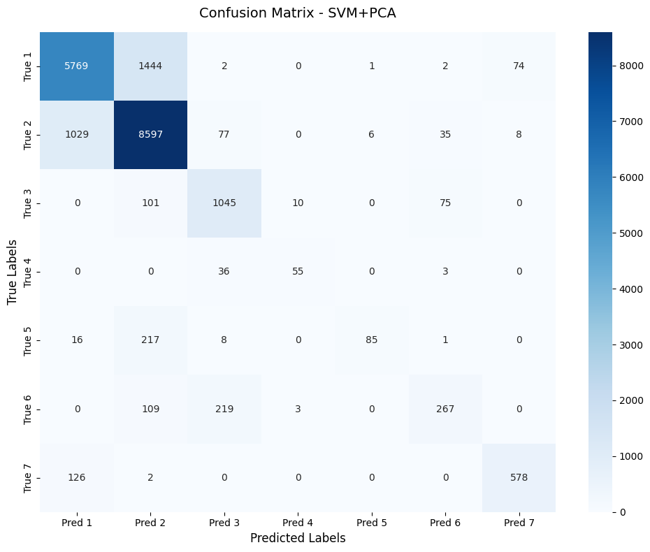

[output not shown]

[output cut: 34 more lines]

[output not shown]

```python
X = df.drop(columns=["Cover_Type"])
y = df["Cover_Type"] - 1

# Stratified sampling: keep 100,000 rows while preserving class distribution
X_sample, _, y_sample, _ = train_test_split(
    X, y,
    train_size=100000,
    stratify=y,
    random_state=42
)

print("Sampled class distribution (normalized):")
print(y_sample.value_counts(normalize=True).round(3))

# Split sampled data into train/test sets (stratified again)
X_train, X_test, y_train, y_test = train_test_split(
    X_sample, y_sample,
    test_size=0.2,
    random_state=42,
    stratify=y_sample
)

print(f"\nTrain set shape: {X_train.shape}, Test set shape: {X_test.shape}")

# Separate continuous and binary features
continuous_cols = [
    col for col in X.columns
    if not col.startswith("Wilderness") and not col.startswith("Soil")
]
binary_cols = [col for col in X.columns if col not in continuous_cols]

# Standardize continuous features (only continuous features need scaling)
scaler = StandardScaler()
X_train_continuous = scaler.fit_transform(X_train[continuous_cols])
X_test_continuous = scaler.transform(X_test[continuous_cols])

# Combine standardized continuous features with original binary features
X_train_processed = np.hstack([X_train_continuous, X_train[binary_cols].values])
X_test_processed = np.hstack([X_test_continuous, X_test[binary_cols].values])

print(f"Processed train set shape: {X_train_processed.shape}")

# ---------------------- 2. PCA Dimensionality Reduction ----------------------
# Step 1: Analyze variance explanation ratio to select optimal components
pca_full = PCA(random_state=42)
pca_full.fit(X_train_processed)

# Calculate cumulative explained variance ratio
cumulative_var_ratio = np.cumsum(pca_full.explained_variance_ratio_)

# Visualize cumulative variance explanation (for component selection)
plt.figure(figsize=(10, 6))
plt.plot(range(1, len(cumulative_var_ratio) + 1), cumulative_var_ratio, 'b-o', linewidth=2, markersize=6)
plt.axhline(y=0.95, color='r', linestyle='--', linewidth=2, label='95% Variance Explained')
plt.axhline(y=0.90, color='g', linestyle='--', linewidth=2, label='90% Variance Explained')
plt.xlabel('Number of Principal Components', fontsize=12)
plt.ylabel('Cumulative Explained Variance Ratio', fontsize=12)
plt.title('PCA Cumulative Variance Explained', fontsize=14, pad=15)
plt.legend(fontsize=10)
plt.grid(True, alpha=0.3)
plt.tight_layout()
plt.show()

# Step 2: Select number of components (explain 95% variance by default)
n_components = np.argmax(cumulative_var_ratio >= 0.95) + 1  # +1 for 1-based indexing
print(f"\nNumber of components needed to explain 95% variance: {n_components}")

# Step 3: Apply PCA with selected components
pca = PCA(n_components=n_components, random_state=42)
X_train_pca = pca.fit_transform(X_train_processed)
X_test_pca = pca.transform(X_test_processed)

print(f"PCA-reduced train set shape: {X_train_pca.shape}, Test set shape: {X_test_pca.shape}")
print(f"Variance retained by PCA: {cumulative_var_ratio[n_components-1]:.3f}")

# ---------------------- 3. SVM Classification (with PCA) ----------------------
# Train SVM model on PCA-reduced data
svm_pca_clf = SVC(C=10, kernel='rbf', random_state=42, verbose=1)
svm_pca_clf.fit(X_train_pca, y_train)

# Make predictions
y_pred_svm_pca = svm_pca_clf.predict(X_test_pca)

# ---------------------- 4. Model Evaluation ----------------------
print("\n" + "="*50)
print("SVM+PCA Model Evaluation Results")
print("="*50)

# Calculate key metrics
accuracy = accuracy_score(y_test, y_pred_svm_pca)
precision = precision_score(y_test, y_pred_svm_pca, average='macro')
recall = recall_score(y_test, y_pred_svm_pca, average='macro')

print(f"\nAccuracy: {accuracy:.4f}")
print(f"Precision (macro): {precision:.4f}")
print(f"Recall (macro): {recall:.4f}")

# Detailed classification report
print("\nClassification Report:")
print(classification_report(
    y_test, y_pred_svm_pca,
    target_names=[f"Class {i+1}" for i in range(7)]
))

# Confusion matrix visualization
cm = confusion_matrix(y_test, y_pred_svm_pca)
plt.figure(figsize=(10, 8))
sns.heatmap(
    cm,
    annot=True,
    fmt="d",
    cmap="Blues",
    cbar=True,
    xticklabels=[f"Pred {i+1}" for i in range(7)],
    yticklabels=[f"True {i+1}" for i in range(7)]
)
plt.title("Confusion Matrix - SVM+PCA", fontsize=14, pad=15)
plt.xlabel("Predicted Labels", fontsize=12)
plt.ylabel("True Labels", fontsize=12)
plt.tight_layout()
plt.show()

# ---------------------- Optional: Compare with SVM without PCA ----------------------
print("\n" + "="*50)
print("SVM Model (Without PCA) for Comparison")
print("="*50)

# Train SVM on original processed data
svm_original_clf = SVC(C=10, kernel='rbf', random_state=42, verbose=1)
svm_original_clf.fit(X_train_processed, y_train)
y_pred_original = svm_original_clf.predict(X_test_processed)

# Evaluate baseline SVM
print(f"SVM (No PCA) Accuracy: {accuracy_score(y_test, y_pred_original):.4f}")
```